# Final Project

Christopher Rabeony

4/28/2020

```r
getwd()
```

```
## [1] "/Users/chris/Documents/Data Mining"
```

## Read data from UCI repository.

```r
file1 <- url("https://archive.ics.uci.edu/ml/machine-learning-databases/adult/adult.data")
file2 <- url("https://archive.ics.uci.edu/ml/machine-learning-databases/adult/adult.test")
```

```r
train <- read.table(file1, sep = ",", header = FALSE)
test  <- read.table(file2, sep = ",", header = FALSE, skip = 1)
```

```r
# Combine the automated train/test split so we can perform our own splits
data <- rbind(train, test)
data1 <- data

# Label the variable names
colnames(data1) <- c("age", "workclass", "fnlwgt","education", "education_num",
                     "marital_status", "occupation", "relationship", "race", "sex",
                     "capital_gain", "capital_loss",
                     "hours_per_week", "native_country", "income")
```

### Information about the variables.

```r
str(data1)
```

```
## 'data.frame':    48842 obs. of  15 variables:
##  $ age           : int  39 50 38 53 28 37 49 52 31 42 ...
##  $ workclass     : Factor w/ 9 levels " ?"," Federal-gov",..: 8 7 5 5 5 5 5 7 5 5 ...
##  $ fnlwgt        : int  77516 83311 215646 234721 338409 284582 160187 209642 45781 159449 ...
##  $ education     : Factor w/ 16 levels " 10th"," 11th",..: 10 10 12 2 10 13 7 12 13 10 ...
##  $ education_num : int  13 13 9 7 13 14 5 9 14 13 ...
##  $ marital_status: Factor w/ 7 levels " Divorced"," Married-AF-spouse",..: 5 3 1 3 3 3 4 3 5 3 ...
##  $ occupation    : Factor w/ 15 levels " ?"," Adm-clerical",..: 2 5 7 7 11 5 9 5 11 5 ...
##  $ relationship  : Factor w/ 6 levels " Husband"," Not-in-family",..: 2 1 2 1 6 6 2 1 2 1 ...
##  $ race          : Factor w/ 5 levels " Amer-Indian-Eskimo",..: 5 5 5 3 3 5 3 5 5 5 ...
##  $ sex           : Factor w/ 2 levels " Female"," Male": 2 2 2 2 1 1 1 2 1 2 ...
##  $ capital_gain  : int  2174 0 0 0 0 0 0 0 14084 5178 ...
##  $ capital_loss  : int  0 0 0 0 0 0 0 0 0 0 ...
##  $ hours_per_week: int  40 13 40 40 40 40 16 45 50 40 ...
##  $ native_country: Factor w/ 42 levels " ?"," Cambodia",..: 40 40 40 40 6 40 24 40 40 40 ...
##  $ income        : Factor w/ 4 levels " <=50K"," >50K",..: 1 1 1 1 1 1 1 2 2 2 ...
```

### Cleaning the data set.

```r
# trim whitespace from char variables
data1 <- data1 %>%
  mutate_if(is.factor, str_trim)
# find missing data and convert to NA
data1[data1 == "?"] <- NA
```

The dependent variable should only have 2 categories (binary).

```r
table(data1$income)
```

```
##
##  <=50K <=50K.   >50K  >50K.
##  24720  12435   7841   3846
```

```r
# Change income to two factors.
data1$income <- as.character(data1$income)

data1$income[data1$income == "<=50K." |
             data1$income == "<=50K"] <- "<=50K"
data1$income[data1$income == ">50K." |
             data1$income == ">50K"] <- ">50K"

table(data1$income)
```

```
##
## <=50K  >50K
## 37155 11687
```

Combine similar ‘workclass’ categories to reduce number of factors.

```r
# Change employment to include less factors.
data1$workclass <- as.character(data1$workclass)

data1$workclass[data1$workclass == "Without-pay" |
                data1$workclass == "Never-worked"] <- "Jobless"
data1$workclass[is.na(data1$workclass)] <- "Jobless"
data1$workclass[data1$workclass == "State-gov" |
                data1$workclass == "Local-gov"]  <- "govt"
data1$workclass[data1$workclass == "Self-emp-inc" |
                data1$workclass == "Self-emp-not-inc"]  <- "Self-employed"

table(data1$workclass)
```

```
##
##   Federal-gov          govt       Jobless       Private Self-employed
##          1432          5117          2830         33906          5557
```

Convert ‘NA’ observations from ‘occupation’ to unemployed.

```r
# Change the occupation and remove "NA"
data1$occupation <- as.character(data1$occupation)
data1$occupation[is.na(data1$occupation)] <- "Unemployed"
```

Reduced number of factors in ‘marital_status’.

```r
# Combine arbitrary marital status to three factors.
data1$marital_status <- as.character(data1$marital_status)

data1$marital_status[data1$marital_status == "Married-AF-spouse" |
                     data1$marital_status == "Married-civ-spouse" |
                     data1$marital_status == "Married-spouse-absent"] <- "Married"
data1$marital_status[data1$marital_status == "Divorced" |
                     data1$marital_status == "Separated" |
                     data1$marital_status == "Widowed"] <- "Not-Married"

table(data1$marital_status)
```

```
##
##       Married Never-married   Not-Married
##         23044         16117          9681
```

Convert countries to continents to reduce the number of factors.

```r
# Change the native_country variable.
data1$native_country <- as.character(data1$native_country)
data1$native_country[is.na(data1$native_country)] <- "Other"
```

```r
# Reduce countries to their respective continents.
data1$native_country <- as.character(data1$native_country)

north.america <- c("Canada", "Cuba", "Dominican-Republic", "El-Salvador", "Guatemala",
                   "Haiti", "Honduras", "Jamaica", "Mexico", "Nicaragua",
                   "Outlying-US(Guam-USVI-etc)", "Puerto-Rico", "Trinadad&Tobago",
                   "United-States")
asia <- c("Cambodia", "China", "Hong", "India", "Iran", "Japan", "Laos",
          "Philippines", "Taiwan", "Thailand", "Vietnam")
south.america <- c("Columbia", "Ecuador", "Peru")
europe <- c("England", "France", "Germany", "Greece", "Holand-Netherlands",
            "Hungary", "Ireland", "Italy", "Poland", "Portugal", "Scotland",
            "Yugoslavia")
other <- c("South", "?", "Other")

data1$native_country[data1$native_country %in% north.america] <- "North-America"
data1$native_country[data1$native_country %in% asia]  <- "Asia"
data1$native_country[data1$native_country %in% south.america] <- "South-America"
data1$native_country[data1$native_country %in% europe] <-  "Europe"
data1$native_country[data1$native_country %in% other] <- "Other"

table(data1$native_country)
```

```
##
##          Asia        Europe North-America         Other South-America
##           981           780         45933           972           176
```

Education.

```r
table(data1$education_num)
```

```
##
##     1     2     3     4     5     6     7     8     9    10    11    12    13
##    83   247   509   955   756  1389  1812   657 15784 10878  2061  1601  8025
##    14    15    16
##  2657   834   594
```

Set levels of discrete variables.

```r
data1$workclass <- as.factor(data1$workclass)
data1$marital_status <- as.factor(data1$marital_status)
data1$occupation <- as.factor(data1$occupation)
data1$relationship <- as.factor(data1$relationship)
data1$race <- as.factor(data1$race)
data1$sex <- as.factor(data1$sex)
data1$native_country <- as.factor(data1$native_country)
```

Remove extraneous variables we will not be using in our analysis.

```r
new_var <- names(data1) %in% c("fnlwgt", "education", "capital_gain", "capital_loss")
data1 <- data1[!new_var]
str(data1)
```

```
## 'data.frame':    48842 obs. of  11 variables:
##  $ age           : int  39 50 38 53 28 37 49 52 31 42 ...
##  $ workclass     : Factor w/ 5 levels "Federal-gov",..: 2 5 4 4 4 4 4 5 4 4 ...
##  $ education_num : int  13 13 9 7 13 14 5 9 14 13 ...
##  $ marital_status: Factor w/ 3 levels "Married","Never-married",..: 2 1 3 1 1 1 1 1 2 1 ...
##  $ occupation    : Factor w/ 15 levels "Adm-clerical",..: 1 4 6 6 10 4 8 4 10 4 ...
##  $ relationship  : Factor w/ 6 levels "Husband","Not-in-family",..: 2 1 2 1 6 6 2 1 2 1 ...
##  $ race          : Factor w/ 5 levels "Amer-Indian-Eskimo",..: 5 5 5 3 3 5 3 5 5 5 ...
##  $ sex           : Factor w/ 2 levels "Female","Male": 2 2 2 2 1 1 1 2 1 2 ...
##  $ hours_per_week: int  40 13 40 40 40 40 16 45 50 40 ...
##  $ native_country: Factor w/ 5 levels "Asia","Europe",..: 3 3 3 3 3 3 3 3 3 3 ...
##  $ income        : chr  "<=50K" "<=50K" "<=50K" "<=50K" ...
```

```r
head(data1)
```

```
##   age     workclass education_num marital_status        occupation
## 1  39          govt            13  Never-married      Adm-clerical
## 2  50 Self-employed            13        Married   Exec-managerial
## 3  38       Private             9    Not-Married Handlers-cleaners
## 4  53       Private             7        Married Handlers-cleaners
## 5  28       Private            13        Married    Prof-specialty
## 6  37       Private            14        Married   Exec-managerial
##    relationship  race    sex hours_per_week native_country income
## 1 Not-in-family White   Male             40  North-America  <=50K
## 2       Husband White   Male             13  North-America  <=50K
## 3 Not-in-family White   Male             40  North-America  <=50K
## 4       Husband Black   Male             40  North-America  <=50K
## 5          Wife Black Female             40  North-America  <=50K
## 6          Wife White Female             40  North-America  <=50K
```

### Preliminary Analysis

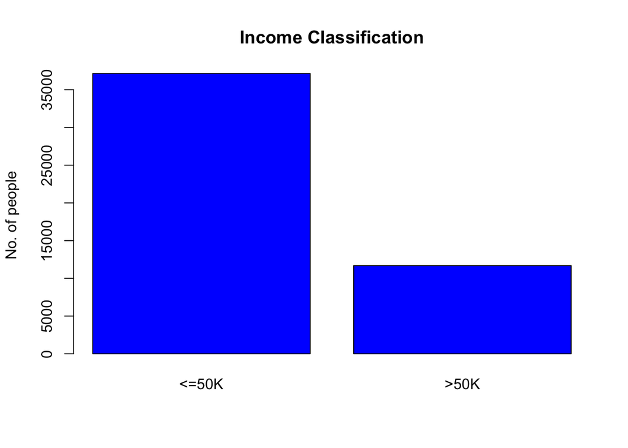

```r
# Plot the number of observations that make over $50,000 and under $50,000
barplot(table(data1$income),  main='Income Classification', col='blue', ylab ='No. of people')
```

As we can see, there’s an inbalance in the data.

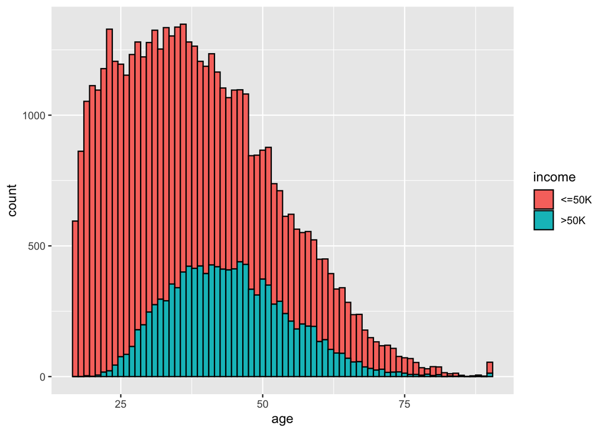

```r
## Histogram of age by income group
ggplot(data1, aes(age)) + geom_histogram(aes(fill = income), color='black', binwidth=1)
```

From this plot we can see that the distribution of people who make above 50K peaks out at a higher age than the distribution of people who make less than 50K.

### Variable Selection

#### Forward/Backward Selection

```r
data1$income <- as.factor(data1$income)
model_glm <- glm(income ~ ., data = data1, family = binomial('logit'))
summary(model_glm)
```

```
##
## Call:
## glm(formula = income ~ ., family = binomial("logit"), data = data1)
##
## Deviance Residuals:
##     Min       1Q   Median       3Q      Max
## -2.6811  -0.5653  -0.2178  -0.0444   3.6657
##
## Coefficients:
##                              Estimate Std. Error z value Pr(>|z|)
## (Intercept)                 -7.007396   0.258458 -27.112  < 2e-16 ***
## age                          0.029068   0.001239  23.464  < 2e-16 ***
## workclassgovt               -0.698545   0.081509  -8.570  < 2e-16 ***
## workclassJobless            -1.504834   0.806899  -1.865 0.062187 .
## workclassPrivate            -0.445598   0.072659  -6.133 8.64e-10 ***
## workclassSelf-employed      -0.697567   0.080218  -8.696  < 2e-16 ***
## education_num                0.295101   0.007064  41.775  < 2e-16 ***
## marital_statusNever-married -1.166399   0.124328  -9.382  < 2e-16 ***
## marital_statusNot-Married   -0.729234   0.123980  -5.882 4.06e-09 ***
## occupationArmed-Forces       0.557996   0.736649   0.757 0.448763
## occupationCraft-repair       0.055735   0.061285   0.909 0.363116
## occupationExec-managerial    0.820862   0.058666  13.992  < 2e-16 ***
## occupationFarming-fishing   -1.047153   0.106058  -9.873  < 2e-16 ***
## occupationHandlers-cleaners -0.684706   0.108126  -6.332 2.41e-10 ***
## occupationMachine-op-inspct -0.313417   0.078791  -3.978 6.96e-05 ***
## occupationOther-service     -0.941373   0.091201 -10.322  < 2e-16 ***
## occupationPriv-house-serv   -1.673695   0.614746  -2.723 0.006477 **
## occupationProf-specialty     0.594619   0.060739   9.790  < 2e-16 ***
## occupationProtective-serv    0.472721   0.097940   4.827 1.39e-06 ***
## occupationSales              0.296337   0.062788   4.720 2.36e-06 ***
## occupationTech-support       0.538021   0.085375   6.302 2.94e-10 ***
## occupationTransport-moving  -0.136321   0.076496  -1.782 0.074740 .
## occupationUnemployed         0.342856   0.808091   0.424 0.671362
## relationshipNot-in-family   -0.893903   0.121830  -7.337 2.18e-13 ***
## relationshipOther-relative  -1.369748   0.171453  -7.989 1.36e-15 ***
## relationshipOwn-child       -1.831671   0.151714 -12.073  < 2e-16 ***
## relationshipUnmarried       -1.157174   0.137223  -8.433  < 2e-16 ***
## relationshipWife             1.178262   0.076883  15.325  < 2e-16 ***
## raceAsian-Pac-Islander       0.530144   0.200095   2.649 0.008062 **
## raceBlack                    0.325594   0.175522   1.855 0.063596 .
## raceOther                    0.342261   0.249489   1.372 0.170112
## raceWhite                    0.500519   0.167450   2.989 0.002798 **
## sexMale                      0.736100   0.057460  12.811  < 2e-16 ***
## hours_per_week               0.030584   0.001232  24.830  < 2e-16 ***
## native_countryEurope         0.371703   0.165509   2.246 0.024716 *
## native_countryNorth-America  0.224515   0.132293   1.697 0.089677 .
## native_countryOther         -0.073318   0.148817  -0.493 0.622242
## native_countrySouth-America -1.219385   0.357141  -3.414 0.000639 ***
## ---
## Signif. codes:  0 '***' 0.001 '**' 0.01 '*' 0.05 '.' 0.1 ' ' 1
##
## (Dispersion parameter for binomial family taken to be 1)
##
##     Null deviance: 53751  on 48841  degrees of freedom
## Residual deviance: 34308  on 48804  degrees of freedom
## AIC: 34384
##
## Number of Fisher Scoring iterations: 7
```

This logistic regression model appears to fit the data well. To explore the possibility of the model being parsimonious, both the forward and backward stepwise selection algorithms using AIC are performed.

```r
income_full <- model_glm  # full model is the model just fitted
income_null <- glm(income ~ 1, data = data1, family = binomial('logit'))
```

```r
# Backward selection.
step1 <- step(income_full, trace = F,
              scope = list(lower=formula(income_null), upper=formula(income_full)),
              k = 2, direction = 'backward')
step1$coefficients
```

```
##                 (Intercept)                         age
##                 -7.00739589                  0.02906793
##               workclassgovt            workclassJobless
##                 -0.69854543                 -1.50483412
##            workclassPrivate      workclassSelf-employed
##                 -0.44559758                 -0.69756726
##               education_num marital_statusNever-married
##                  0.29510133                 -1.16639884
##   marital_statusNot-Married      occupationArmed-Forces
##                 -0.72923373                  0.55799640
##      occupationCraft-repair   occupationExec-managerial
##                  0.05573548                  0.82086249
##   occupationFarming-fishing occupationHandlers-cleaners
##                 -1.04715332                 -0.68470582
## occupationMachine-op-inspct     occupationOther-service
##                 -0.31341696                 -0.94137256
##   occupationPriv-house-serv    occupationProf-specialty
##                 -1.67369463                  0.59461867
##   occupationProtective-serv             occupationSales
##                  0.47272094                  0.29633715
##      occupationTech-support  occupationTransport-moving
##                  0.53802075                 -0.13632082
##        occupationUnemployed   relationshipNot-in-family
##                  0.34285621                 -0.89390283
##  relationshipOther-relative       relationshipOwn-child
##                 -1.36974768                 -1.83167125
##       relationshipUnmarried            relationshipWife
##                 -1.15717391                  1.17826234
##      raceAsian-Pac-Islander                   raceBlack
##                  0.53014369                  0.32559351
##                   raceOther                   raceWhite
##                  0.34226075                  0.50051907
##                     sexMale              hours_per_week
##                  0.73609970                  0.03058350
##        native_countryEurope native_countryNorth-America
##                  0.37170303                  0.22451509
##         native_countryOther native_countrySouth-America
##                 -0.07331834                 -1.21938501
```

```r
# Forward Selection
step2 <- step(income_full, trace = F,
              scope = list(lower=formula(income_null), upper=formula(income_full)),
              k = 2, direction = 'forward')
step2$coefficients
```

```
##                 (Intercept)                         age
##                 -7.00739589                  0.02906793
##               workclassgovt            workclassJobless
##                 -0.69854543                 -1.50483412
##            workclassPrivate      workclassSelf-employed
##                 -0.44559758                 -0.69756726
##               education_num marital_statusNever-married
##                  0.29510133                 -1.16639884
##   marital_statusNot-Married      occupationArmed-Forces
##                 -0.72923373                  0.55799640
##      occupationCraft-repair   occupationExec-managerial
##                  0.05573548                  0.82086249
##   occupationFarming-fishing occupationHandlers-cleaners
##                 -1.04715332                 -0.68470582
## occupationMachine-op-inspct     occupationOther-service
##                 -0.31341696                 -0.94137256
##   occupationPriv-house-serv    occupationProf-specialty
##                 -1.67369463                  0.59461867
##   occupationProtective-serv             occupationSales
##                  0.47272094                  0.29633715
##      occupationTech-support  occupationTransport-moving
##                  0.53802075                 -0.13632082
##        occupationUnemployed   relationshipNot-in-family
##                  0.34285621                 -0.89390283
##  relationshipOther-relative       relationshipOwn-child
##                 -1.36974768                 -1.83167125
##       relationshipUnmarried            relationshipWife
##                 -1.15717391                  1.17826234
##      raceAsian-Pac-Islander                   raceBlack
##                  0.53014369                  0.32559351
##                   raceOther                   raceWhite
##                  0.34226075                  0.50051907
##                     sexMale              hours_per_week
##                  0.73609970                  0.03058350
##        native_countryEurope native_countryNorth-America
##                  0.37170303                  0.22451509
##         native_countryOther native_countrySouth-America
##                 -0.07331834                 -1.21938501
```

Both the forward and backward stepwise selection algorithms give the same model as the initial fit. Thus, the original model is chosen and model diagnostics are to follow.

### Logistic Regression for our original UNBALANCED dataset.

```r
table(data1$income)
```

```
##
## <=50K  >50K
## 37155 11687
```

Let’s test how logistic regression peforms on our original unbalanced dataset.

```r
# Split our training and testing data into a 80%-20% ratio.
split <- sample(dim(data1)[1], 0.8*dim(data1)[1])
train <- data1[split,]
test  <- data1[-split,]
```

```r
# Logistic regression using data1 our unbalanced dataset
model_glm <- glm(income ~ ., data = train, family = "binomial")
summary(model_glm)
```

```
##
## Call:
## glm(formula = income ~ ., family = "binomial", data = train)
##
## Deviance Residuals:
##     Min       1Q   Median       3Q      Max
## -2.7152  -0.5656  -0.2168  -0.0458   3.6388
##
## Coefficients:
##                              Estimate Std. Error z value Pr(>|z|)
## (Intercept)                 -6.994993   0.289351 -24.175  < 2e-16 ***
## age                          0.029057   0.001387  20.948  < 2e-16 ***
## workclassgovt               -0.736597   0.092279  -7.982 1.44e-15 ***
## workclassJobless            -1.777604   1.085207  -1.638  0.10142
## workclassPrivate            -0.510941   0.082377  -6.202 5.56e-10 ***
## workclassSelf-employed      -0.762274   0.090956  -8.381  < 2e-16 ***
## education_num                0.295943   0.007878  37.564  < 2e-16 ***
## marital_statusNever-married -1.103098   0.138758  -7.950 1.87e-15 ***
## marital_statusNot-Married   -0.698282   0.138563  -5.039 4.67e-07 ***
## occupationArmed-Forces       0.454009   0.772449   0.588  0.55670
## occupationCraft-repair       0.095291   0.069000   1.381  0.16727
## occupationExec-managerial    0.887771   0.065986  13.454  < 2e-16 ***
## occupationFarming-fishing   -0.982371   0.117971  -8.327  < 2e-16 ***
## occupationHandlers-cleaners -0.587037   0.120334  -4.878 1.07e-06 ***
## occupationMachine-op-inspct -0.237855   0.087889  -2.706  0.00680 **
## occupationOther-service     -0.877436   0.101620  -8.634  < 2e-16 ***
## occupationPriv-house-serv   -1.402398   0.624102  -2.247  0.02464 *
## occupationProf-specialty     0.649319   0.068277   9.510  < 2e-16 ***
## occupationProtective-serv    0.533522   0.110171   4.843 1.28e-06 ***
## occupationSales              0.370799   0.070444   5.264 1.41e-07 ***
## occupationTech-support       0.567131   0.095665   5.928 3.06e-09 ***
## occupationTransport-moving  -0.117636   0.086480  -1.360  0.17374
## occupationUnemployed         0.640376   1.086268   0.590  0.55551
## relationshipNot-in-family   -0.933349   0.136034  -6.861 6.83e-12 ***
## relationshipOther-relative  -1.384433   0.194112  -7.132 9.88e-13 ***
## relationshipOwn-child       -1.894434   0.170031 -11.142  < 2e-16 ***
## relationshipUnmarried       -1.217204   0.153847  -7.912 2.54e-15 ***
## relationshipWife             1.196182   0.085512  13.989  < 2e-16 ***
## raceAsian-Pac-Islander       0.563244   0.223276   2.523  0.01165 *
## raceBlack                    0.311214   0.195983   1.588  0.11229
## raceOther                    0.438168   0.278271   1.575  0.11535
## raceWhite                    0.477352   0.187126   2.551  0.01074 *
## sexMale                      0.723629   0.064074  11.294  < 2e-16 ***
## hours_per_week               0.030461   0.001371  22.216  < 2e-16 ***
## native_countryEurope         0.360149   0.183886   1.959  0.05017 .
## native_countryNorth-America  0.240534   0.147503   1.631  0.10295
## native_countryOther         -0.002045   0.165887  -0.012  0.99016
## native_countrySouth-America -1.118587   0.400563  -2.793  0.00523 **
## ---
## Signif. codes:  0 '***' 0.001 '**' 0.01 '*' 0.05 '.' 0.1 ' ' 1
##
## (Dispersion parameter for binomial family taken to be 1)
##
##     Null deviance: 42932  on 39072  degrees of freedom
## Residual deviance: 27377  on 39035  degrees of freedom
## AIC: 27453
##
## Number of Fisher Scoring iterations: 7
```

In order to return probabilities, we must specify type = “response”. (The default setting is type = “link”, which corresponds to the log odds value.)

```r
head(predict(model_glm, type = "response"))
```

```
##        2986       29925       29710       37529        2757       45404
## 0.005305835 0.110095279 0.211833787 0.026721229 0.860324832 0.002426636
```

Traditionally, a midpoint value such as 0.5 is used to “categorize” the probabilities. (This is actually equivalen to specifyng type = “link” and using a threshhold value of 0.)

```r
train_prob <- predict(model_glm, test, type = 'response')
train_pred <- ifelse(predict(model_glm, type = "response") > 0.5, "Yes", "No")
head(train_pred)
```

```
##  2986 29925 29710 37529  2757 45404
##  "No"  "No"  "No"  "No" "Yes"  "No"
```

Probably the most common thing that is done to evaluate a classificiation models is to compare the actual response values with the predicted ones using a cross-table, which is often called a confusion matrix. This matrix can be generated with the base table() function.

```r
# Making predictions on the train set.
train_tab <- table(predicted = train_pred, actual = train$income)
train_tab
```

```
##          actual
## predicted <=50K  >50K
##       No  27488  4152
##       Yes  2265  5168
```

```r
# Making Predictions on the test set
test_pred <- ifelse(predict(model_glm, newdata = test, type = "response") > 0.5, "Yes", "No")
test_tab <- table(predicted = test_pred, actual = test$income)
test_tab
```

```
##          actual
## predicted <=50K >50K
##       No   6799 1089
##       Yes   603 1278
```

Perhaps unsurprisingly, the most common metrics for evaluating logistic regression models are test accuracy (which is simply the additive inverse of the error rate). These metrics can be calculated directly from the confustion matrix.

```r
# Function to calculate our accuracy, precision, and f1 scores for our tables.
calculate_stats <- function(table) {
  n = sum(table) # number of instances
  diag = diag(table) # number of correctly classified instances per class
  rowsums = apply(table, 1, sum) # number of instances per class
  colsums = apply(table, 2, sum) # number of predictions per class
  accuracy = sum(diag) / n
  precision = diag / colsums
  recall = diag / rowsums
  f1 = 2 * precision * recall / (precision + recall)
  return(data.frame(accuracy, precision, recall, f1))
}
```

```r
# Calculate our accuracy, precision, recall, and f1 score for our test data.
calculate_stats(test_tab)
```

```
##        accuracy precision    recall        f1
## <=50K 0.8267991 0.9185355 0.8619422 0.8893394
## >50K  0.8267991 0.5399240 0.6794258 0.6016949
```

```r
# Calculate our accuracy, precision, recall, and f1 score for our training data.
calculate_stats(train_tab)
```

```
##        accuracy precision    recall        f1
## <=50K 0.8357689 0.9238732 0.8687737 0.8954767
## >50K  0.8357689 0.5545064 0.6952778 0.6169641
```

### Naive Bayes

```r
# Create model and test accuracy table
bayes_model <- naiveBayes(income ~ ., data = train)
bayes_pred <- predict(bayes_model, test)
```

```r
# Confusion matrix for Bayes
bayes_table <- table(bayes_pred, test$income)
bayes_table
```

```
##
## bayes_pred <=50K >50K
##      <=50K  6029  566
##      >50K   1373 1801
```

```r
# Our evaluation metrics for Naive Bayes.
calculate_stats(bayes_table)
```

```
##       accuracy precision    recall        f1
## <=50K 0.801515 0.8145096 0.9141774 0.8614703
## >50K  0.801515 0.7608787 0.5674228 0.6500632
```

### Decision Tree

```r
library(rpart)
```

```r
# Implementing Decision Tree
tree_adult_model <- rpart(income~.,data = train)
tree_pred_prob <- predict(tree_adult_model, newdata = test, type = 'prob')
tree_pred_income <- predict(tree_adult_model,test ,type = "class")
# an extra argument (type = "class") is required to directly classify prediction into classes
```

```r
tree_tab <- table(test$income, tree_pred_income)
tree_tab
```

```
##        tree_pred_income
##         <=50K >50K
##   <=50K  6948  454
##   >50K   1317 1050
```

```r
calculate_stats(tree_tab)
```

```
##        accuracy precision    recall        f1
## <=50K 0.8187123 0.8406534 0.9386652 0.8869599
## >50K  0.8187123 0.6981383 0.4435995 0.5424955
```

Here is how to plot the decision tree:

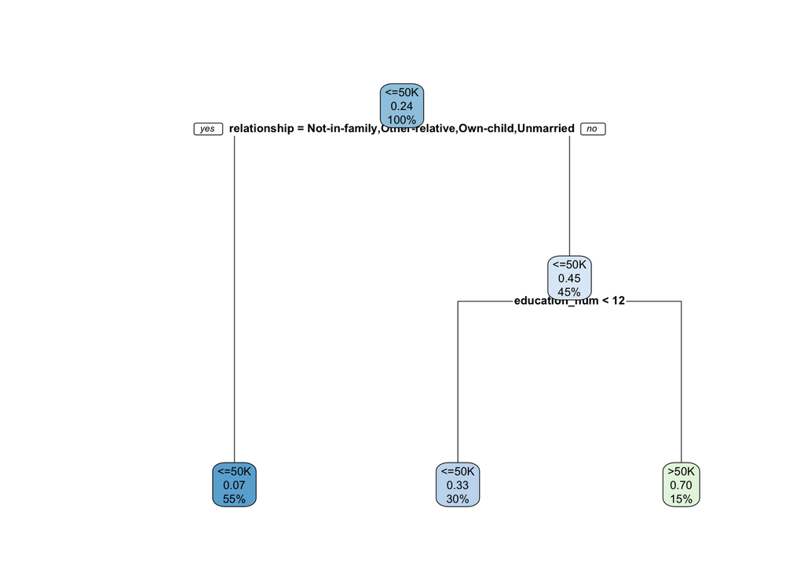

```r
library(rpart.plot)
rpart.plot(tree_adult_model,cex = 0.6)
```

### Random Forest

Random forests (RF) improves predictive accuracy by generating a large number of bootstrapped trees.

```r
# Generate optimal model
rf_model <- randomForest(income ~ ., data = train, ntree = 1000)
rf_pred.prob <- predict(rf_model, newdata = test, type = 'prob')
rf_pred <- predict(rf_model, newdata = test, type = 'class')
```

```r
# Confusion matrix
rf_table <- table(rf_pred, test$income)
rf_table
```

```
##
## rf_pred <=50K >50K
##   <=50K  6802 1028
##   >50K    600 1339
```

```r
# Our evaluation metrics for Random Forests
calculate_stats(rf_table)
```

```
##        accuracy precision    recall        f1
## <=50K 0.8333504 0.9189408 0.8687101 0.8931197
## >50K  0.8333504 0.5656950 0.6905621 0.6219229
```

[figure not shown]

```r
# create a prediction object
pr <- prediction(train_prob, test$income)
prf <- performance(pr, measure = "tpr", x.measure = "fpr")

# create a data frame for TP and FP rates
dd1 <- data.frame(FP = prf@x.values[[1]], TP = prf@y.values[[1]])

# RF
pr2 <- prediction(rf_pred.prob[,2], test$income)
prf2 <- performance(pr2, measure = "tpr", x.measure = "fpr")
dd2 <- data.frame(FP = prf2@x.values[[1]], TP = prf2@y.values[[1]])

# NB
pr3 <- prediction(as.numeric(bayes_pred), test$income)
prf3 <- performance(pr3, measure = "tpr", x.measure = "fpr")
dd3 <- data.frame(FP = prf3@x.values[[1]], TP = prf3@y.values[[1]])

# CART
pr4 <- prediction(tree_pred_prob[,2], test$income)
prf4 <- performance(pr4, measure = "tpr", x.measure = "fpr")
dd4 <- data.frame(FP = prf4@x.values[[1]], TP = prf4@y.values[[1]])

# plot ROC curve for logistic regression
g <- ggplot() +
  geom_line(data = dd1, aes(x = FP, y = TP, color = 'Logistic Regression')) +
  geom_line(data = dd2, aes(x = FP, y = TP, color = 'Random Forests')) +
  geom_line(data = dd3, aes(x = FP, y = TP, color = 'CART')) +
  geom_line(data = dd4, aes(x = FP, y = TP, color = 'Naive Bayes')) +
  geom_segment(aes(x = 0, xend = 1, y = 0, yend = 1)) +
  ggtitle('ROC Curve') +
  labs(x = 'False Positive Rate', y = 'True Positive Rate')

g + scale_colour_manual(name = 'Classifier', values = c('Logistic Regression'='#E69F00', 'Random Forests'='#D55E00', 'Naive Bayes'='#0072B2', 'CART'='#009E73'))
```

```r
# AUC
auc <- rbind(performance(pr, measure = 'auc')@y.values[[1]],
             performance(pr2, measure = 'auc')@y.values[[1]],
             performance(pr3, measure = 'auc')@y.values[[1]],
             performance(pr4, measure = 'auc')@y.values[[1]])
rownames(auc) <- (c('Logistic Regression', 'Random Forests', 'Naive Bayes', 'CART'))
colnames(auc) <- 'Area Under ROC Curve'
round(auc, 4)
```

```
##                     Area Under ROC Curve
## Logistic Regression               0.8845
## Random Forests                    0.8729
## Naive Bayes                       0.7877
## CART                              0.8099
```

ROC curve is a plot of true positive rate against false positive rate under all threshold values. Confusion matrix is a measurement of overall prediction accuracy. Since the majority of observations in the data set has income less than $50,000 a year, sensitivity and specificity contribute to the overall accuracy by different weights. The four different classifiers are compared using ROC curve.

### Balancing our Data via Downsampling.

```r
# Unbalanced data
table(data1$income)
```

```
##
## <=50K  >50K
## 37155 11687
```

```r
# Create balanced dataset HERE (run for b trials)
less <- which(data1$income == "<=50K")
greater <- which(data1$income == ">50K")
downsample0 <- sample(less, length(greater), replace = FALSE)
data2 <- rbind(data1[greater,], data1[downsample0,])
```

```r
# Balanced data
table(data2$income)
```

```
##
## <=50K  >50K
## 11687 11687
```

```r
# Change train/test split ratio HERE
# to use unbalenced (original data) - use data1
# to use balanced data - use data2
split2 <- sample(dim(data2)[1], 0.8*dim(data2)[1])
train2 <- data2[split2,]
test2  <- data2[-split2,]
```

### Logistic Regression (unpenalized) for balanced data

```r
# Making predictions on test set
model_glm2 <- glm(income ~ ., family = "binomial", train2)
adult_pr.test2 <- predict(model_glm2, type = "response", newdata = test2)
```

```r
train_pred2 <- ifelse(predict(model_glm2, type = "response") > 0.5, "Yes", "No")
head(train_pred2)
```

```
## 40460 20079 16162 27638 15473 47028
## "Yes"  "No" "Yes" "Yes"  "No"  "No"
```

```r
# Making predictions on the train set.
train_tab2 <- table(predicted = train_pred2, actual = train2$income)
train_tab2
```

```
##          actual
## predicted <=50K >50K
##       No   7166 1509
##       Yes  2175 7849
```

```r
# Making Predictions on the test set
test_pred2 <- ifelse(predict(model_glm2, newdata = test2, type = "response") > 0.5, "Yes", "No")
test_tab2 <- table(predicted = test_pred2, actual = test2$income)
test_tab2
```

```
##          actual
## predicted <=50K >50K
##       No   1811  363
##       Yes   535 1966
```

```r
# Our evaluation metrics for the balanced training data.
calculate_stats(train_tab2)
```

```
##        accuracy precision    recall        f1
## <=50K 0.8029841 0.7671556 0.8260519 0.7955151
## >50K  0.8029841 0.8387476 0.7830208 0.8099267
```

```r
# Our evaluation metrics for the balanced testing data.
calculate_stats(test_tab2)
```

```
##        accuracy precision    recall        f1
## <=50K 0.8079144 0.7719523 0.8330267 0.8013274
## >50K  0.8079144 0.8441391 0.7860856 0.8140787
```

### Naive Bayes for Balanced Data

```r
# Create model and test accuracy table
bayes_model2 <- naiveBayes(income ~ ., data = train2)
bayes_pred2 <- predict(bayes_model, test2)
```

```r
# Confusion matrix for Bayes
bayes_table2 <- table(bayes_pred2, test2$income)
bayes_table2
```

```
##
## bayes_pred2 <=50K >50K
##       <=50K  1913  570
##       >50K    433 1759
```

```r
# Our evaluation metrics for Naive Bayes.
calculate_stats(bayes_table2)
```

```
##        accuracy precision    recall        f1
## <=50K 0.7854545 0.8154305 0.7704390 0.7922965
## >50K  0.7854545 0.7552598 0.8024635 0.7781464
```

### Decision Tree For Balanced Data

```r
# Implementing Decision Tree
tree_adult_model2 <- rpart(income~.,data = train2)
pred_income2 <- predict(tree_adult_model2,test2 ,type = "class")
# an extra argument (type = "class") is required to directly classify prediction into classes
```

```r
tree_tab2 <- table(test2$income, pred_income2)
tree_tab2
```

```
##        pred_income2
##         <=50K >50K
##   <=50K  1777  569
##   >50K    429 1900
```

```r
calculate_stats(tree_tab2)
```

```
##        accuracy precision    recall        f1
## <=50K 0.7865241 0.8055304 0.7574595 0.7807557
## >50K  0.7865241 0.7695423 0.8158008 0.7919967
```

Here is how to plot the decision tree:

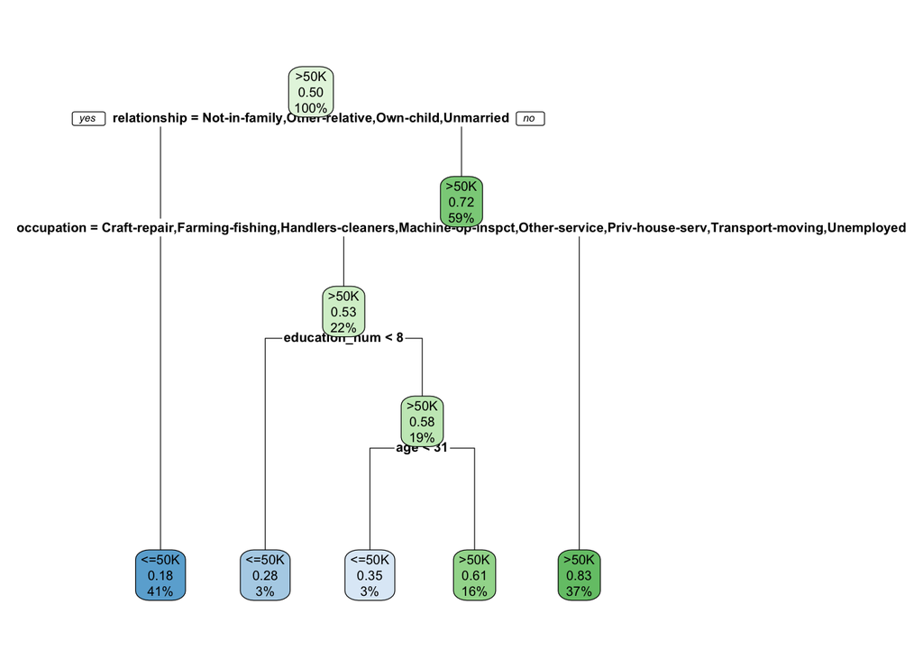

```r
rpart.plot(tree_adult_model2 ,cex = 0.6)
```

### Random Forest

Random forests (RF) improves predictive accuracy by generating a large number of bootstrapped trees.

```r
# Generate optimal model
rf_model2 <- randomForest(income ~ ., data = train2, ntree = 1000)
rf_pred.prob2 <- predict(rf_model2, newdata = test2, type = 'prob')
rf_pred2 <- predict(rf_model2, newdata = test2, type = 'class')
```

```r
# Confusion matrix
rf_table2 <- table(rf_pred2, test2$income)
rf_table2
```

```
##
## rf_pred2 <=50K >50K
##    <=50K  1840  380
##    >50K    506 1949
```

```r
# Our evaluation metrics for Naive Bayes.
calculate_stats(rf_table2)
```

```
##        accuracy precision    recall        f1
## <=50K 0.8104813 0.7843137 0.8288288 0.8059571
## >50K  0.8104813 0.8368398 0.7938900 0.8147993
```